# GAMLSS modelling of aggregate UK electricity demand: solution

1. Load data and fit a basic Gaussian GAM:

```r
library(mgcViz); library(gridExtra)
data("UKload")

form <- NetDemand~s(wM,k=20,bs='cr') + s(wM_s95,k=20,bs='cr') +
        s(Posan, k=30, bs = "cc") + Dow + s(Trend,k=4,bs='cr') +
        NetDemand.48 + Holy

fit0 <- gamV(form, data = UKload, aViz = list(nsim = 50))
```

2. Look for patterns in the residuals conditional mean

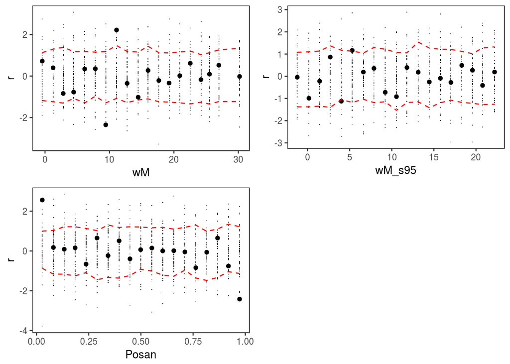

```r
pl <- list()
pl[[1]] <- ( check1D(fit0, "wM") + l_gridCheck1D(gridFun = mean, stand = "sc") )$ggObj      # OK
pl[[2]] <- ( check1D(fit0, "wM_s95") + l_gridCheck1D(gridFun = mean, stand = "sc") )$ggObj  # OK
pl[[3]] <- ( check1D(fit0, "Posan") + l_gridCheck1D(gridFun = mean, stand = "sc") )$ggObj   # Not OK

grid.arrange(grobs = pl, ncol = 2)
```

Plots for `wM` and `wM_s95` are kind of fine. But in plot for `Posan`, we have positive mean residuals in January and negative in December. Maybe using a cyclic effect for `Posan` was a mistake: the effect at the beginning of January does not match that at the end of December! This might require more careful handling of winter holidays.

3. Remove cyclic smooth and re-check:

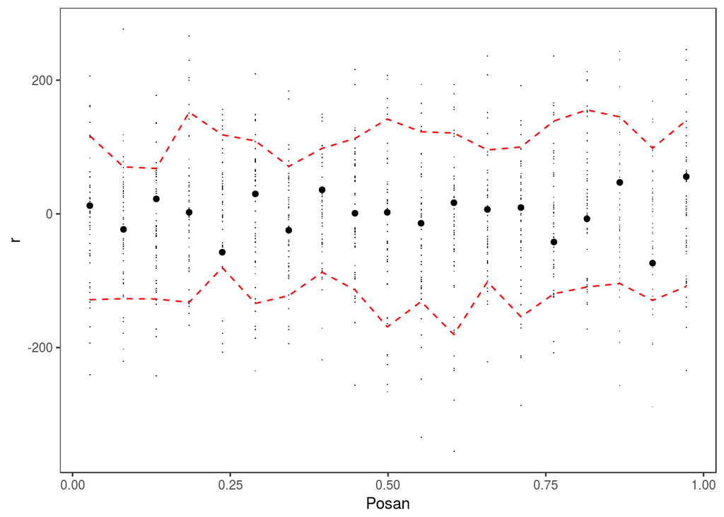

```r
form <- NetDemand ~ s(wM,k=20,bs='cr') +
                    s(wM_s95,k=20,bs='cr') +
                    s(Posan,bs='cr',k=30) +  # <- Changed `cc` to `cr`
                    Dow + s(Trend,k=4) + NetDemand.48 + Holy

fit1 <- gamV(form, data = UKload, aViz = list(nsim = 50))

# Pattern in residuals mean is gone!
check1D(fit1, "Posan") + l_gridCheck1D(gridFun = mean)
```

```r
AIC( fit0, fit1 ) # Some improvement
```

```
##            df      AIC
## fit0 48.12895 33515.39
## fit1 45.73625 33423.51
```

The fit seems better without the cyclic smooth. However:

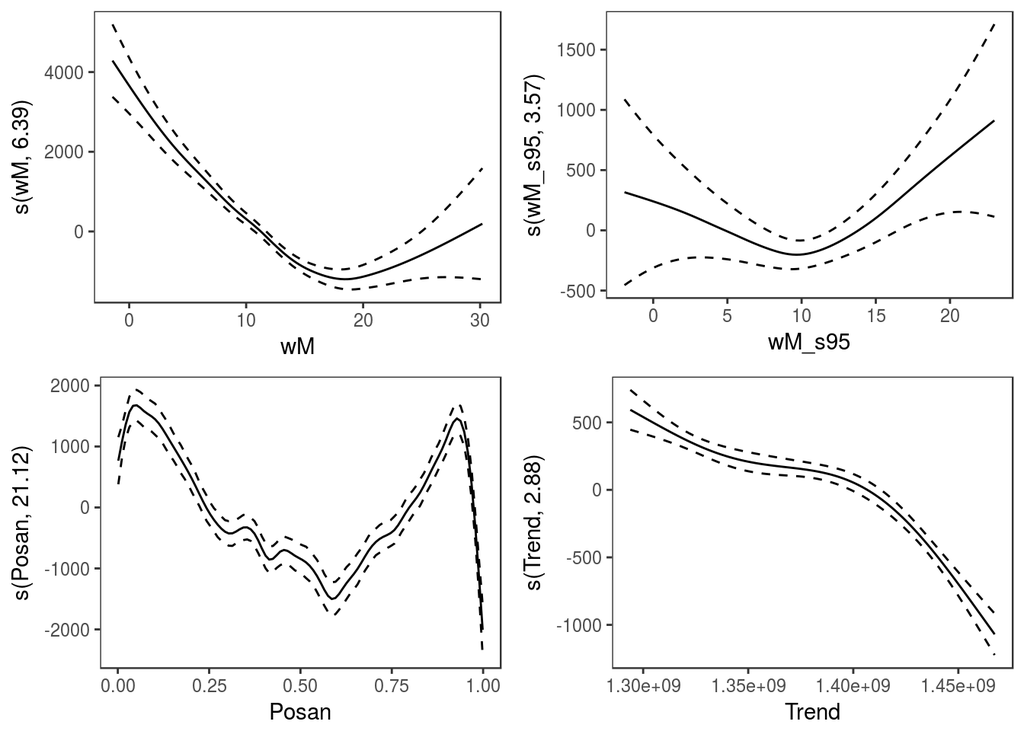

```r
print(plot(fit1), pages = 1)
```

```r
tmp <- check(fit1)
```

```
##
## Method: REML   Optimizer: outer newton
## full convergence after 4 iterations.
## Gradient range [-0.001888527,0.001255441]
## (score 16671.19 & scale 968372).
## Hessian positive definite, eigenvalue range [0.8398987,997.6139].
## Model rank =  79 / 79
##
## Basis dimension (k) checking results. Low p-value (k-index<1) may
## indicate that k is too low, especially if edf is close to k'.
##
##              k'   edf k-index p-value
## s(wM)     19.00  6.39    0.99    0.30
## s(wM_s95) 19.00  3.57    1.01    0.70
## s(Posan)  29.00 21.12    0.95    0.02 *
## s(Trend)   3.00  2.88    1.10    1.00
## ---
## Signif. codes:  0 '***' 0.001 '**' 0.01 '*' 0.05 '.' 0.1 ' ' 1
```

the p-value of `Posan` is quite low in `check.gam` and this effect also drops sharply in December. Maybe an adaptive smooth would be better.

4. Fit model and plot smooths

```r
form <- NetDemand ~ s(wM,k=20,bs='cr') +
                    s(wM_s95,k=20,bs='cr') +
                    s(Posan,bs='ad',k=30) +  # <- Changed `cr` to `ad`
                    Dow + s(Trend,k=4) + NetDemand.48 + Holy
fit2 <- gamV(form, data = UKload, aViz = list(nsim = 50))

AIC( fit1, fit2 ) # Lower AIC!
```

```
##            df      AIC
## fit1 45.73625 33423.51
## fit2 40.37521 33414.34
```

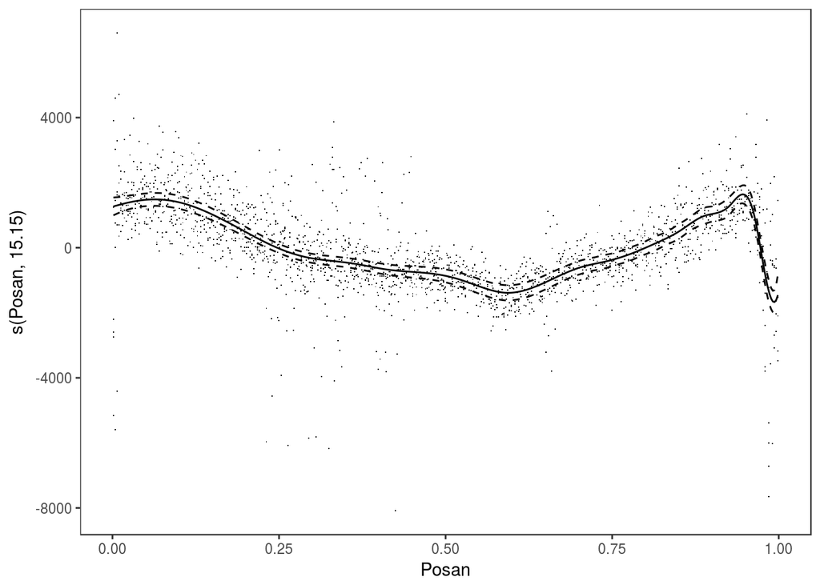

```r
plot(sm(fit2, 3), n = 400) + l_points() + l_fitLine() + l_ciLine()
```

We now look at the conditional variance of the residuals. First series of checks:

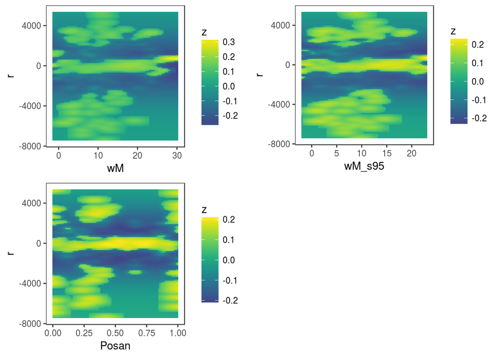

```r
pl <- list()
pl[[1]] <- ( check1D(fit2, "wM") + l_densCheck(n = c(100, 100), tol = -1) )$ggObj
pl[[2]] <- ( check1D(fit2, "wM_s95") + l_densCheck(n = c(100, 100), tol = -1) )$ggObj
pl[[3]] <- ( check1D(fit2, "Posan") + l_densCheck(n = c(100, 100), tol = -1) )$ggObj

grid.arrange(grobs = pl, ncol = 2) # Some evidence of heteroscedasticity
```

The residuals seem over-dispersed for `wM` < 20 and for `Posan` < 0.5 or `Posan` > 0.9. Second series of checks:

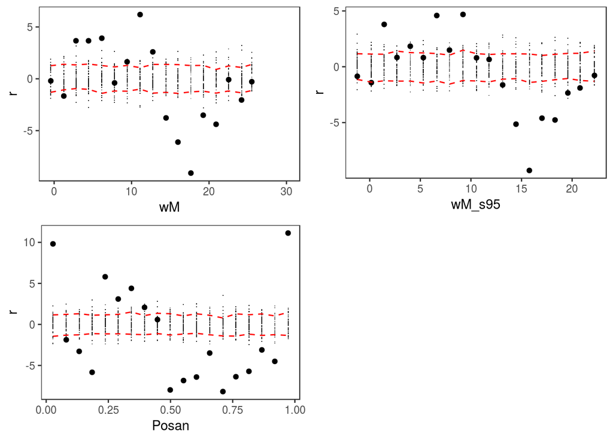

```r
pl <- list()
pl[[1]] <- ( check1D(fit2, "wM") + l_gridCheck1D(gridFun = sd, stand = "sc") )$ggObj
pl[[2]] <- ( check1D(fit2, "wM_s95") + l_gridCheck1D(gridFun = sd, stand = "sc") )$ggObj
pl[[3]] <- ( check1D(fit2, "Posan") + l_gridCheck1D(gridFun = sd, stand = "sc") )$ggObj

grid.arrange(grobs = pl, ncol = 2) # More evidence of heteroscedasticity
```

The variance changes a lot along all the three variables. We could address this by fitting a GAMLSS model with variable scale.

5. Fitting `gaulss` GAMLSS model

```r
form <- list(NetDemand ~ s(wM,k=20,bs='cr') +
             s(wM_s95,k=20,bs='cr') +
             s(Posan,bs='ad',k=30) +
             Dow + s(Trend,k=4) + NetDemand.48 + Holy,
             ~ s(wM_s95,k=10,bs='cr') +
               s(Posan,bs='cr',k=20) +
               Dow)

fit3 <- gamV(form, family = gaulss, data = UKload, aViz = list(nsim = 50))

AIC(fit2, fit3)
```

```
##            df      AIC
## fit2 40.37521 33414.34
## fit3 74.23823 32424.12
```

The AIC has improved quite a lot. Now we repeat the variance checks:

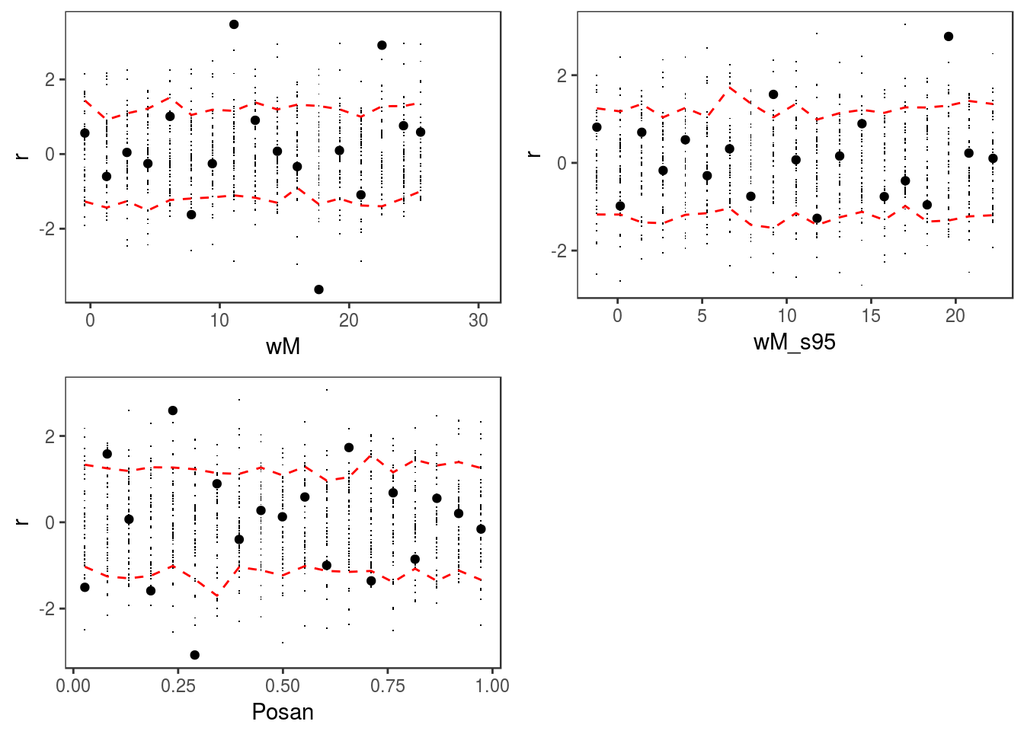

```r
pl <- list()
pl[[1]] <- ( check1D(fit3, "wM") + l_gridCheck1D(gridFun = sd, stand = "sc") )$ggObj
pl[[2]] <- ( check1D(fit3, "wM_s95") + l_gridCheck1D(gridFun = sd, stand = "sc") )$ggObj
pl[[3]] <- ( check1D(fit3, "Posan") + l_gridCheck1D(gridFun = sd, stand = "sc") )$ggObj

grid.arrange(grobs = pl, ncol = 2)
```

There variance is much less variable, relative to the location-only Gaussian model.

6. Looking at skewness. Now we do a global residual check using `qq`:

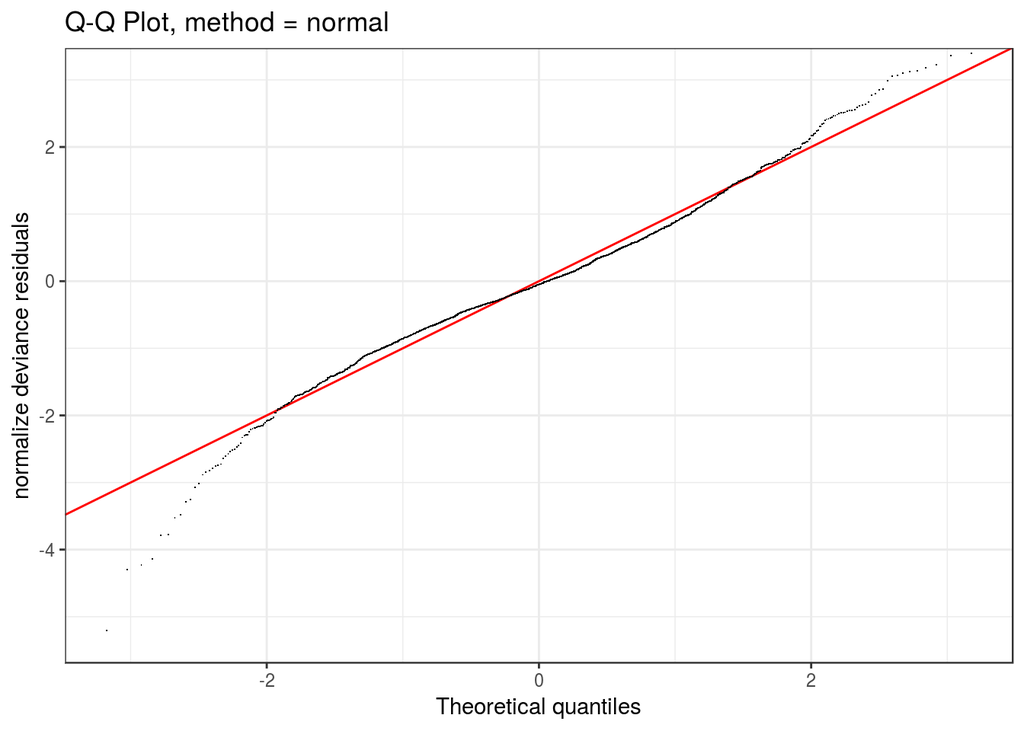

```r
qq(fit3)
```

There is evidence of fat tails, and possibly skewness to the left. Let’s look at how the skewness changes with the covariates:

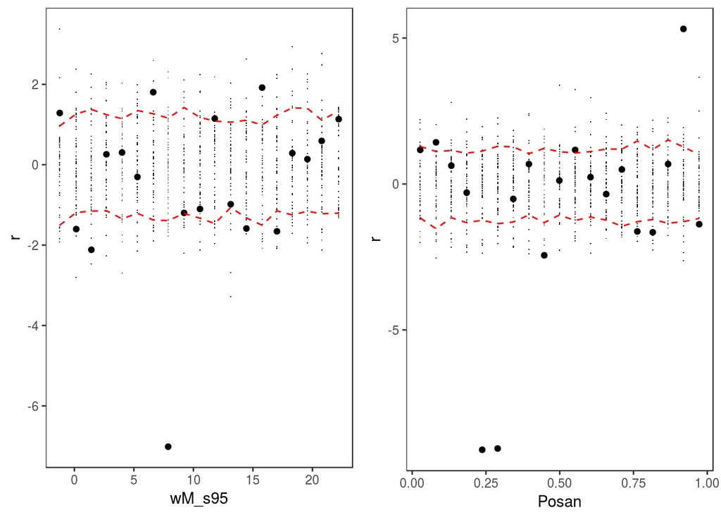

```r
library(e1071)
pl <- list()
pl[[1]] <- ( check1D(fit3, "wM_s95") + l_gridCheck1D(gridFun = skewness, stand = "sc") )$ggObj
pl[[2]] <- ( check1D(fit3, "Posan") + l_gridCheck1D(gridFun = skewness, stand = "sc") )$ggObj

grid.arrange(grobs = pl, ncol = 2)
```

Both plots show several departures from the model based estimates (the model is Gaussian, so the distribution of the response is symmetric). Residuals seem very strongly skewed to the left for $\text{Posan} \approx 0.25$, which corresponds roughly to March.

7. Fitting shash GAMLSS model:

```r
library(mgcFam)
form <- list(NetDemand ~ s(wM,k=20,bs='cr') +
               s(wM_s95,k=20,bs='cr') +
               s(Posan,bs='ad',k=30) +
               s(Trend,k=4) + NetDemand.48 + Holy + Dow,
             ~ s(wM_s95,k=10,bs='cr') +
               s(Posan,bs='cr',k=20) +
               Dow,
             ~ s(Posan, k = 10, bs='cr') + Dow,
             ~ 1) # If convergence problems arise use
                  # ~ -1 + s(Holy, bs = "re", sp = 1e6) in place of ~ 1

fit4 <- gamV(form, family = shash, data = UKload,
             aViz = list(nsim = 50))

AIC(fit3, fit4) # Decreased again by a lot
```

```
##            df      AIC
## fit3 74.23823 32424.12
## fit4 80.15185 32159.12
```

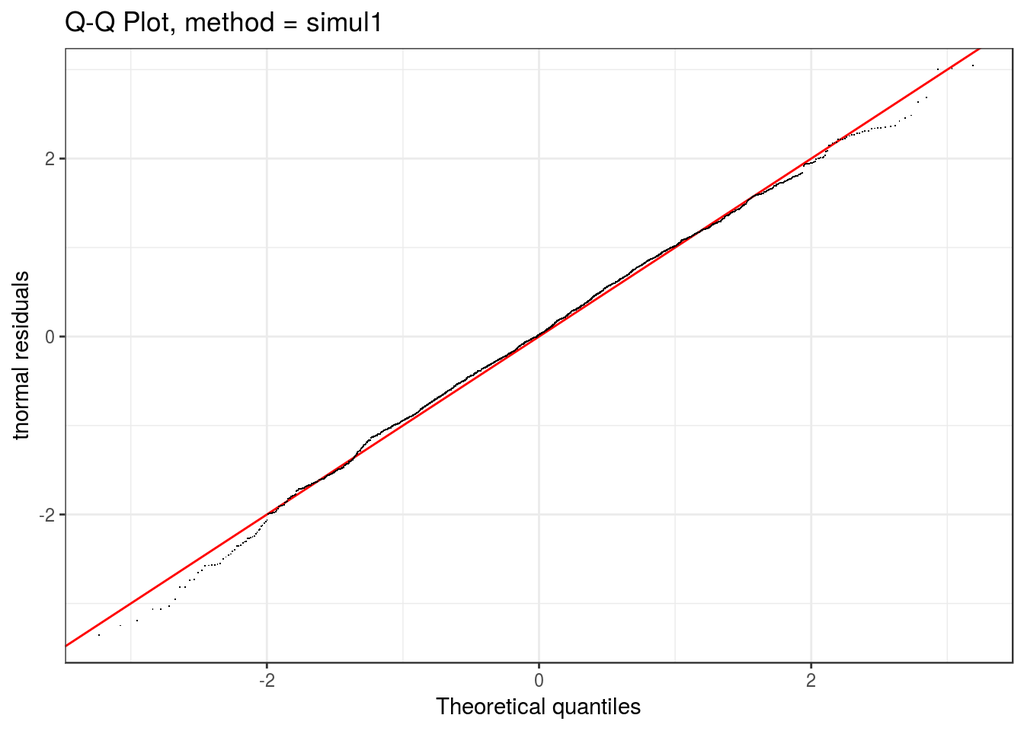

```r
qq(fit4, method = "simul1", rep = 50) # Better on left tail
```

There is a clear improvement, especially in the left tail of the QQ-plot. Now we re-check how the skewness varies along the covariates:

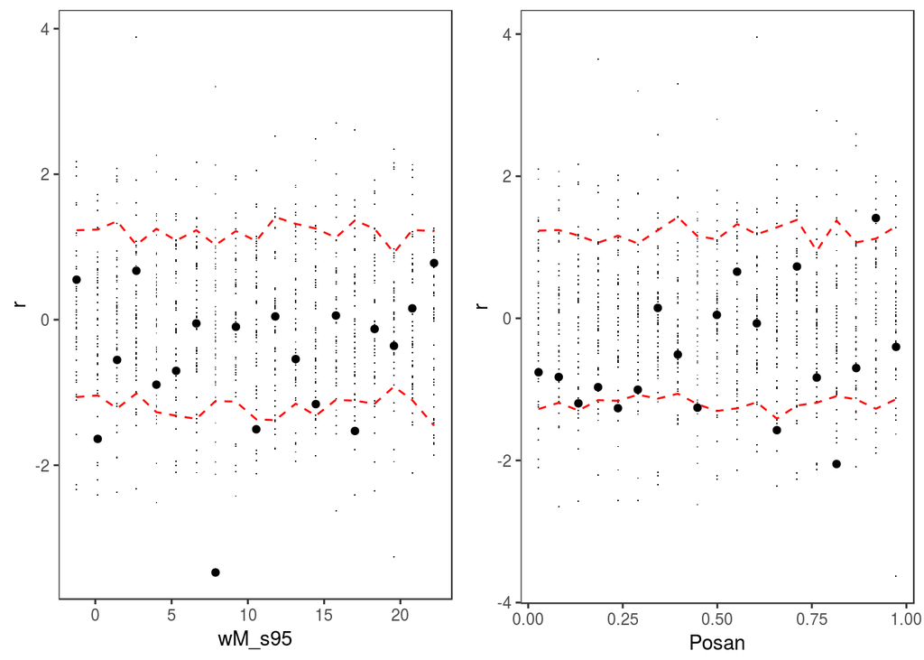

```r
pl <- list()
pl[[1]] <- ( check1D(fit4, "wM_s95") + l_gridCheck1D(gridFun = skewness, stand = "sc") )$ggObj
pl[[2]] <- ( check1D(fit4, "Posan") + l_gridCheck1D(gridFun = skewness, stand = "sc") )$ggObj

grid.arrange(grobs = pl, ncol = 2)
```

Along `Posan` there is a quite a lot of improvement, the points with very low skewness in March have disappeared. More limited improvement along `wM_s95`.

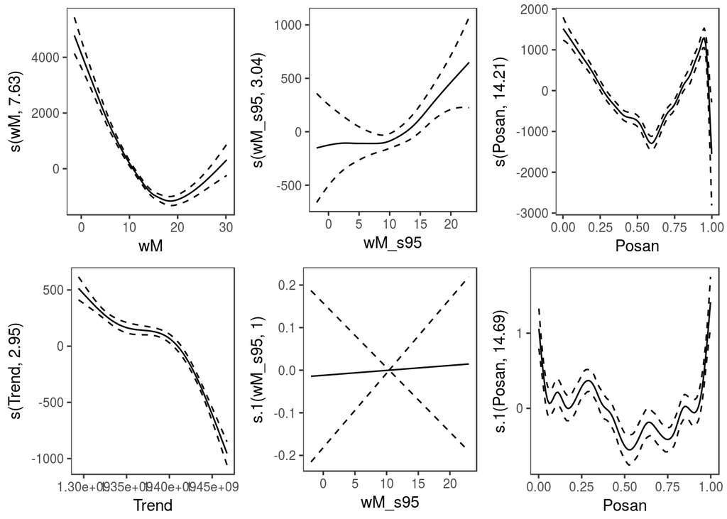

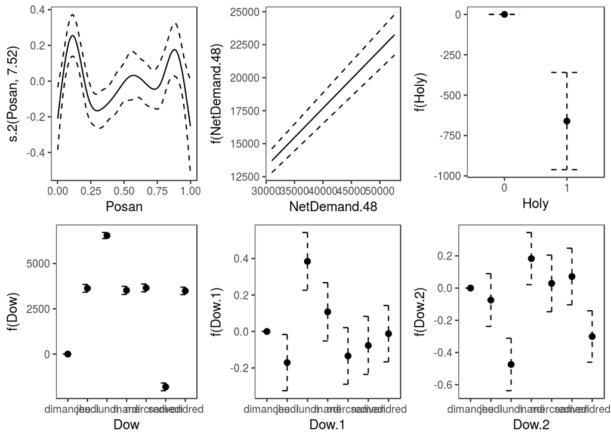

```r
print(plot(fit4, allTerms = TRUE), pages = 2, ask = F)
```